# TIL: Analytics Providers

It’s Numbers that Differ!

Vincent Warmerdam koaning.io  
2021-09-01

I’m hosting my calmcode.io and I was curious about the usage numbers. This got me using [Plausible](https://plausible.io) and although I very much like the service, I recognize that it only tracks traffic in the front end. This got me curious, would the number be any different if I was tracking via the backend instead? This is a service that [Netlify](https://www.netlify.com/products/analytics/) supports so I figured giving it a spin so that I could compare numbers.

The different, turns out, is big!

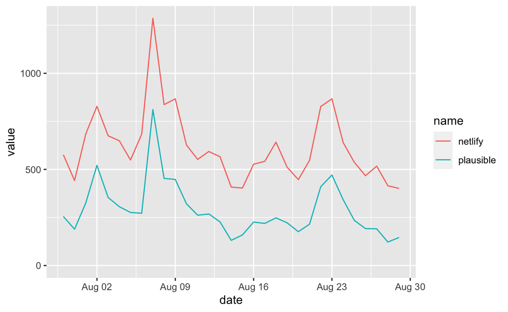

Over the same month, Plausible would report 8994 users while Netlify would report 19112. The difference makes sense to me though, considering the demographic that I get on that website. My audience is mainly developers which, I imagine, are much more likely to have extensions around that block front-end trackers. Even the privacy preserving ones that are hosted by Plausible.

Still. That’s a ~2x difference! That’s huge! Something to keep in mind for anybody that makes websites for developers.